# Laboratory Values Stats - PhysioNet Sepsis Challenge

efg | 2019-04-01

> An expanded training database is now available, containing data from a total of 40,336 subjects. The complete training database (42 MB), consisting of two parts: training set A (20,336 subjects) and B (20,000 subjects).

efg | 2019-05-12

Updated units for Platelets and WBC after PhysioNet forum posting on 2019-04-17 by Gari Clifford.

efg | 2019-05-19

Encountered [pandoc document conversion failed with error 11 #4462](https://github.com/rstudio/rstudio/issues/4462) after R upgrade to 3.6.0 and latest RStudio. Fix in link from RStudio resolved the problem.

# 1 Purpose

The purpose of this notebook is to take a preliminary look at the raw data from 40,336 patients in the PhysioNet 2019 challenge, where some had sepsis and some did not.

The focus of this notebook is on the **Laboratory Values** data (**columns 9 - 34**) and the outcome (column 41)

- `SepsisLabel`. For sepsis patients, `SepsisLabel` is 1 if $t \ge t_{sepsis} - 6$ and 0 if $t < t_{sepsis} - 6$. For non-sepsis patients, `SepsisLabel` is 0.

# 2 Background

The data being analyzed is from the [Early Prediction of Sepsis from Clinical Data: the PhysioNet/Computing in Cardiology Challenge 2019](https://physionet.org/challenge/2019/).

# 3 Exploration

## 3.1 Setup

```r
plotCaptionLeft  <- "Source:  PhysioNet 2019 Sepsis Project"
plotCaptionRight <- paste("efg", format(Sys.time(), "%Y-%m-%d"))
```

### 3.1.1 Packages

```r
library(tidyverse)
library(kableExtra) # kable_styling
library(readxl)

library(gridExtra)
library(grid)

library(e1071)      # skewness, kurtosis
```

### 3.1.2 Helper function

```r
Show <- function(data, caption="", bigMark="")
{
  data                                          %>%
  kable("html",
        caption=caption,
        format.args = list(big.mark=bigMark))   %>%
  kable_styling(bootstrap_options = c("striped", "bordered", "condensed"),
                position = "left", full_width = FALSE)
}
```

### 3.1.3 Laboratory Values List and Units

From file `Laboratory-Values.xlsx` but order by `Quantity` label.

```r
labValues <-
  read_xlsx("Laboratory-Values.xlsx")              %>%
  mutate(Units = ifelse(is.na(Units), "", Units))  %>%
  arrange(Quantity)

labValues %>%
  Show()
```

| Quantity | Units | Description | RangeMin | RangeMax | MinPlotValue | MaxPlotValue | Source |
| --- | --- | --- | --- | --- | --- | --- | --- |
| Alkalinephos | IU/L | Alkaline phosphatase | 36.00 | 92.00 | 0 | 300.0 | http://idgateway.wustl.edu/Normal%20lab%20values.pdf |
| AST | IU/L | Aspartate transaminase | NA | NA | 0 | 250.0 | NA |
| BaseExcess | mmol/L | Measure of excess bicarbonate | NA | NA | -12 | 12.0 | NA |
| Bilirubin_direct | mg/dL | Bilirubin direct | NA | NA | 0 | 6.0 | NA |
| Bilirubin_total | mg/dL | Total bilirubin | NA | NA | 0 | 6.0 | NA |
| BUN | mg/dL | Blood urea nitrogen | 8.00 | 20.00 | 0 | 50.0 | http://idgateway.wustl.edu/Normal%20lab%20values.pdf |
| Calcium | mg/dL | Calcium | NA | NA | 0 | 12.0 | NA |
| Chloride | mmol/L | Chloride | NA | NA | 85 | 125.0 | NA |
| Creatinine | mg/dL | Creatinine | NA | NA | 0 | 5.0 | NA |
| Fibrinogen | mg/dL | Fibrinogen | NA | NA | 0 | 1000.0 | NA |
| FiO2 | % | Fraction of inspired oxygen | 0.00 | 1.00 | 0 | 1.0 | https://en.wikipedia.org/wiki/Fraction_of_inspired_oxygen |
| Glucose | mg/dL | Serum glucose | NA | NA | 0 | 300.0 | NA |
| HCO3 | mmol/L | Bicarbonate | 23.00 | 28.00 | 10 | 40.0 | http://idgateway.wustl.edu/Normal%20lab%20values.pdf |
| Hct | % | Hematocrit | NA | NA | 15 | 50.0 | NA |
| Hgb | g/dL | Hemoglobin | NA | NA | 5 | 17.5 | NA |
| Lactate | mg/dL | Lactic acid | NA | NA | 0 | 7.5 | NA |
| Magnesium | mmol/dL | Magnesium | NA | NA | 1 | 3.5 | NA |
| PaCO2 | mm Hg | Partial pressure of carbon dioxide from arterial blood | 35.00 | 45.00 | 10 | 75.0 | http://idgateway.wustl.edu/Normal%20lab%20values.pdf |
| pH |  | Measure of acidity or basicity | 7.38 | 7.44 | 7 | 7.7 | http://idgateway.wustl.edu/Normal%20lab%20values.pdf |
| Phosphate | mg/dL | Phosphate | NA | NA | 0 | 10.0 | NA |
| Platelets | count*10^3/µL | Platelets | NA | NA | 0 | 600.0 | NA |
| Potassium | mmol/L | Potassium | NA | NA | 2 | 7.5 | NA |
| PTT | seconds | partial thromboplastin time | NA | NA | 10 | 100.0 | NA |
| SaO2 | % | Oxygen saturation from arterial blood | 80.00 | 100.00 | 90 | 100.0 | http://idgateway.wustl.edu/Normal%20lab%20values.pdf |
| TroponinI | ng/mL | Troponinl | NA | NA | 0 | 2.0 | NA |
| WBC | count*10^3/µL | Leukocyte count | NA | NA | 0 | 30.0 | NA |

The lab values are sorted here by Quantity name, which is a different order than in the file.

### 3.1.4 Load PhysioNet 2019 Challenge Combined Data

```r
load(file = "../../data/PhysioNet-2019-Raw-Data-A.RData")
dim(allDataA)
```

```
[1] 790215     43
```

```r
load(file = "../../data/PhysioNet-2019-Raw-Data-B.RData")
dim(allDataB)
```

```
[1] 761995     43
```

Combine A and B

```r
allData <- bind_rows(allDataA, allDataB)
dim(allData)
```

```
## [1] 1552210      43
```

Verify Laboratory Values match

```r
all(labValues$Quantity %in% names(allData))
```

```
[1] TRUE
```

Sample Laboratory Values

```r
allData                        %>%
  select( patient, ICULOS,
          labValues$Quantity,
          SepsisLabel)         %>%
  head()                       %>%
  Show()                       %>%
  scroll_box(width = "800px")
```

| patient | ICULOS | Alkalinephos | AST | BaseExcess | Bilirubin_direct | Bilirubin_total | BUN | Calcium | Chloride | Creatinine | Fibrinogen | FiO2 | Glucose | HCO3 | Hct | Hgb | Lactate | Magnesium | PaCO2 | pH | Phosphate | Platelets | Potassium | PTT | SaO2 | TroponinI | WBC | SepsisLabel |
| --- | --- | --- | --- | --- | --- | --- | --- | --- | --- | --- | --- | --- | --- | --- | --- | --- | --- | --- | --- | --- | --- | --- | --- | --- | --- | --- | --- | --- |
| p000001 | 1 | NA | NA | NA | NA | NA | NA | NA | NA | NA | NA | NA | NA | NA | NA | NA | NA | NA | NA | NA | NA | NA | NA | NA | NA | NA | NA | 0 |
| p000001 | 2 | NA | NA | NA | NA | NA | NA | NA | NA | NA | NA | NA | NA | NA | NA | NA | NA | NA | NA | NA | NA | NA | NA | NA | NA | NA | NA | 0 |
| p000001 | 3 | NA | NA | NA | NA | NA | NA | NA | NA | NA | NA | NA | NA | NA | NA | NA | NA | NA | NA | NA | NA | NA | NA | NA | NA | NA | NA | 0 |
| p000001 | 4 | NA | NA | 24 | NA | NA | NA | NA | NA | NA | NA | NA | NA | NA | NA | NA | NA | NA | 100 | 7.36 | NA | NA | NA | NA | NA | NA | NA | 0 |
| p000001 | 5 | NA | NA | NA | NA | NA | NA | NA | NA | NA | NA | 0.28 | NA | NA | NA | NA | NA | NA | NA | NA | NA | NA | NA | NA | NA | NA | NA | 0 |
| p000001 | 6 | NA | NA | NA | NA | NA | NA | NA | NA | NA | NA | NA | NA | NA | NA | NA | NA | NA | NA | NA | NA | NA | NA | NA | NA | NA | NA | 0 |

## 3.2 Sepsis Label

```r
table(allData$SepsisLabel, useNA = "ifany")
```

```
      0       1
1524294   27916
```

## 3.3 Laboratory Values

```r
for (i in 1:nrow(labValues))
{
  titleLine <- labValues$Quantity[i]
  if (titleLine != labValues$Description[i])
  {
    titleLine <- paste(titleLine, " - ", labValues$Description[i])
  }

  cat("\n###", titleLine, "\n")   # dynamic header in markdown

  if (labValues$Quantity[i] %in% c("Platelets", "WBC"))
  {
    cat("\nUnits updated after PhysioNet forum posting by Gari Clifford on 2019-04-17\n")
  }

  rawData <-
    allData                                      %>%
    select(labValues$Quantity[i], SepsisLabel)   %>%
    na.omit()                                    %>%
    mutate(Sepsis = recode(SepsisLabel,
                           "0" = "Not Sepsis",
                           "1" = "Sepsis"))      %>%
    mutate(Sepsis = as.factor(Sepsis))

  counts <- table(rawData$Sepsis)
  rawDataLabels <- names(counts)
  rawDataCounts <- str_trim( format(counts, big.mark = ",") )

  if (nchar(labValues$Units[i]) == 0)
  {
    quantityUnits <- ""    # display no units
  } else {
    quantityUnits <- paste0("[", labValues$Units[i], "]")
  }

  valueBoxplot <-
    ggplot(rawData,
           aes_string("Sepsis",
                      labValues$Quantity[i],
                      fill = "Sepsis"))                        +
    geom_boxplot(notch = TRUE)                                 +
    ylim(labValues$MinPlotValue[i], labValues$MaxPlotValue[i]) +
    scale_x_discrete(labels = paste(rawDataLabels,
                                    paste0("n = ",
                                           rawDataCounts),
                                    sep = "\n") )              +
    labs(title = titleLine,
         x = "",
         y = paste0(labValues$Quantity[i], quantityUnits))     +
    scale_fill_brewer(palette = "Pastel1", direction = -1)     +
    theme(legend.position = "none",
          plot.margin = unit(c(5, 5, 5, 12), "mm"))            +
    coord_flip()

  valueDensity <-
    ggplot(rawData, aes_string(x = labValues$Quantity[i]))     +
    geom_density(aes_string(group = "Sepsis", fill = "Sepsis"),
                 alpha = 0.5)                                  +
    xlim(labValues$MinPlotValue[i], labValues$MaxPlotValue[i]) +
    labs(x = paste0(labValues$Quantity[i], quantityUnits),
         caption = c(plotCaptionLeft, plotCaptionRight))       +
    scale_fill_brewer(palette = "Pastel1", direction = -1)     +
    theme(plot.caption = element_text(hjust = c(0, 1)),
          legend.position = "none",
          plot.margin = unit(c(5, 5, 5, 20), "mm"))

  suppressWarnings( grid.arrange(valueBoxplot, valueDensity) )

  # mulitple quantile calls not efficient, but fast enough here
  stats <-
    rawData           %>%
    group_by(Sepsis)  %>%
    summarize(N        = n(),
              Distinct = n_distinct(.[1]),
              Mean     = mean(!!rlang::sym(names(rawData)[1])),
              StdDev   = sd(!!rlang::sym(names(rawData)[1])),
              Skewness = skewness(!!rlang::sym(names(rawData)[1])),
              Kurtosis = kurtosis(!!rlang::sym(names(rawData)[1])),
              Min      = min(!!rlang::sym(names(rawData)[1])),
              Q5       = quantile(!!rlang::sym(names(rawData)[1]), 0.05),
              Q25      = quantile(!!rlang::sym(names(rawData)[1]), 0.25),
              Median   = median(!!rlang::sym(names(rawData)[1])),
              Q75      = quantile(!!rlang::sym(names(rawData)[1]), 0.75),
              Q95      = quantile(!!rlang::sym(names(rawData)[1]), 0.95),
              Max      = max(!!rlang::sym(names(rawData)[1])))   %>%
    ungroup()         %>%
    arrange(desc(Sepsis))

  print( stats %>%  Show(bigMark = ",") )

  cat("\n")
}
```

### 3.3.1 Alkalinephos - Alkaline phosphatase

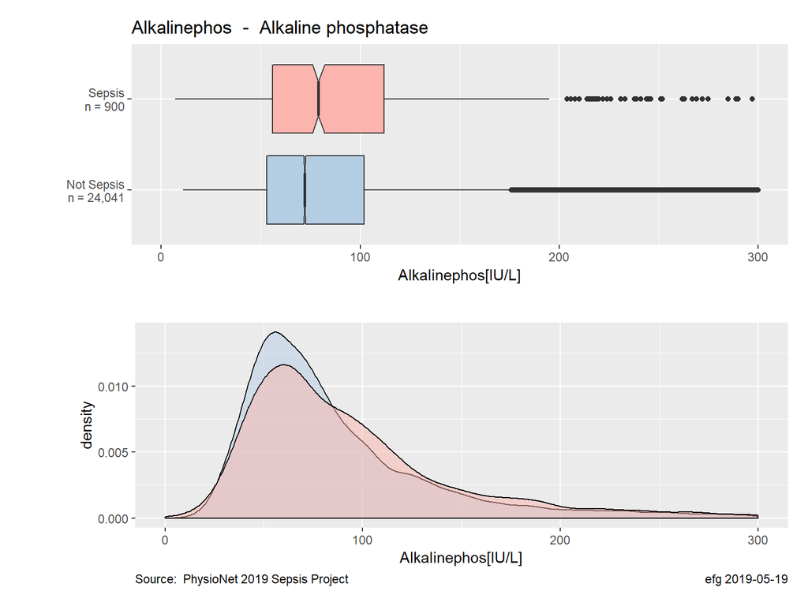

| Sepsis | N | Distinct | Mean | StdDev | Skewness | Kurtosis | Min | Q5 | Q25 | Median | Q75 | Q95 | Max |
| --- | --- | --- | --- | --- | --- | --- | --- | --- | --- | --- | --- | --- | --- |
| Sepsis | 900 | 752 | 110.8433 | 103.2559 | 4.35188 | 29.28749 | 7 | 38 | 57 | 82 | 121 | 301.1 | 1,185 |
| Not Sepsis | 24,041 | 752 | 102.1707 | 120.6990 | 10.17863 | 198.66244 | 11 | 35 | 54 | 73 | 108 | 253.0 | 3,833 |

### 3.3.2 AST - Aspartate transaminase

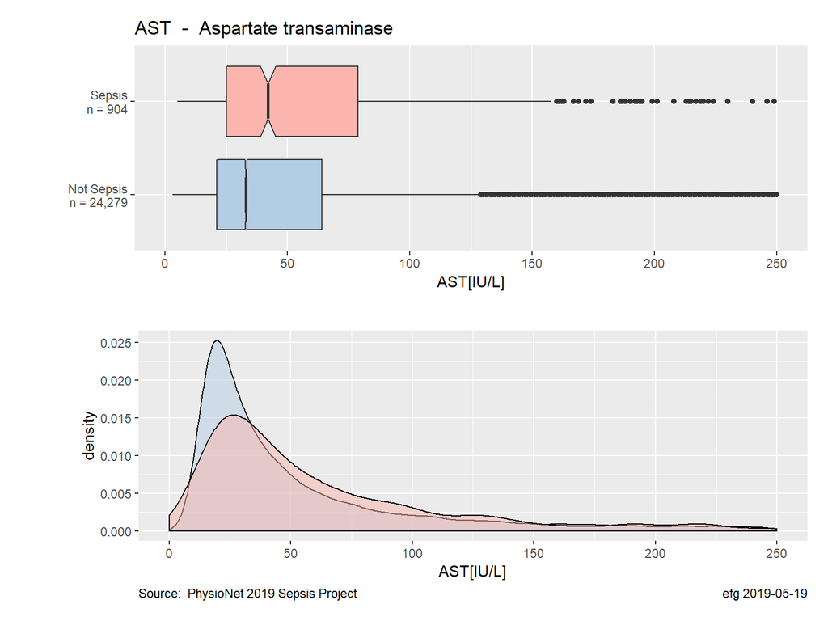

| Sepsis | N | Distinct | Mean | StdDev | Skewness | Kurtosis | Min | Q5 | Q25 | Median | Q75 | Q95 | Max |
| --- | --- | --- | --- | --- | --- | --- | --- | --- | --- | --- | --- | --- | --- |
| Sepsis | 904 | 2,025 | 294.8319 | 905.4145 | 6.199986 | 46.88586 | 5 | 16 | 28 | 53 | 128.25 | 1,403 | 9,602 |
| Not Sepsis | 24,279 | 2,025 | 258.9348 | 853.8343 | 6.447646 | 48.55542 | 3 | 14 | 22 | 41 | 110.00 | 1,121 | 9,961 |

### 3.3.3 BaseExcess - Measure of excess bicarbonate

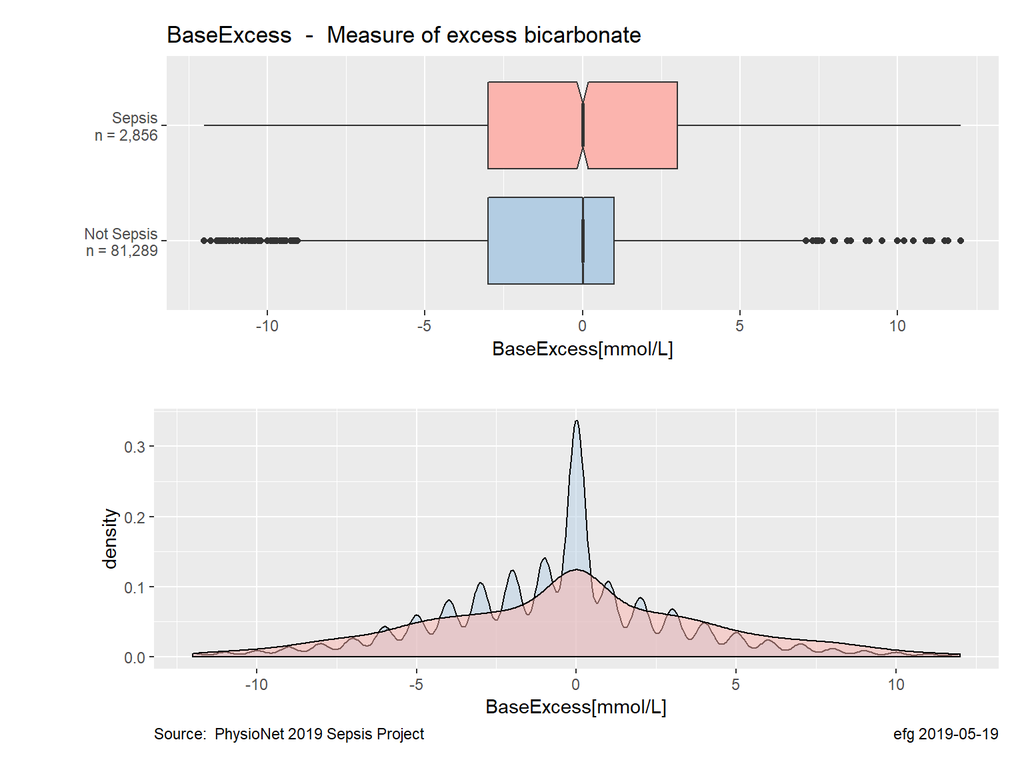

| Sepsis | N | Distinct | Mean | StdDev | Skewness | Kurtosis | Min | Q5 | Q25 | Median | Q75 | Q95 | Max |
| --- | --- | --- | --- | --- | --- | --- | --- | --- | --- | --- | --- | --- | --- |
| Sepsis | 2,856 | 407 | -0.3524685 | 4.962375 | -0.0756001 | 0.7999831 | -18 | -8.8875 | -3 | 0 | 3 | 8 | 21 |
| Not Sepsis | 81,289 | 407 | -0.7017751 | 4.268474 | -0.0000637 | 7.9249789 | -32 | -7.0000 | -3 | 0 | 1 | 6 | 100 |

### 3.3.4 Bilirubin_direct - Bilirubin direct

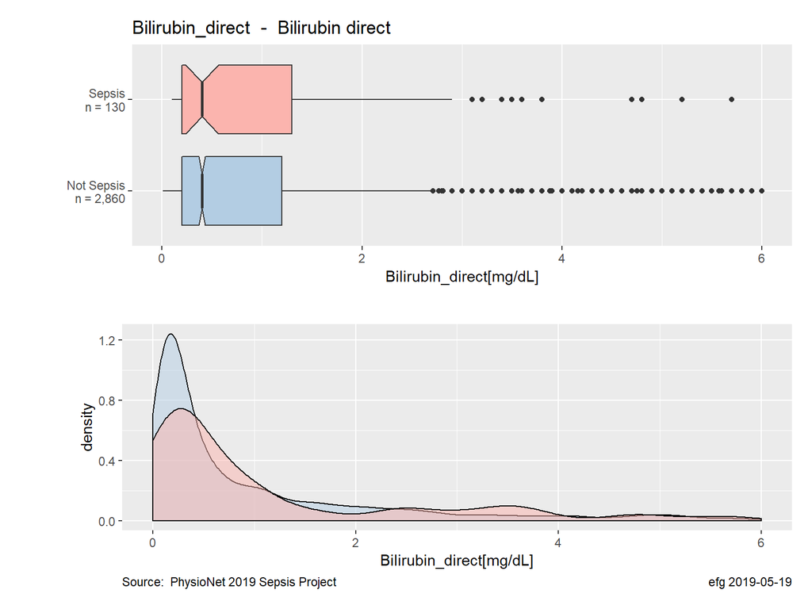

| Sepsis | N | Distinct | Mean | StdDev | Skewness | Kurtosis | Min | Q5 | Q25 | Median | Q75 | Q95 | Max |
| --- | --- | --- | --- | --- | --- | --- | --- | --- | --- | --- | --- | --- | --- |
| Sepsis | 130 | 280 | 2.848077 | 4.931728 | 2.371977 | 4.924209 | 0.10 | 0.1 | 0.2 | 0.65 | 3.05 | 16.320 | 22.2 |
| Not Sepsis | 2,860 | 280 | 1.790182 | 3.622243 | 4.227935 | 22.388262 | 0.01 | 0.1 | 0.2 | 0.40 | 1.70 | 7.705 | 37.5 |

### 3.3.5 Bilirubin_total - Total bilirubin

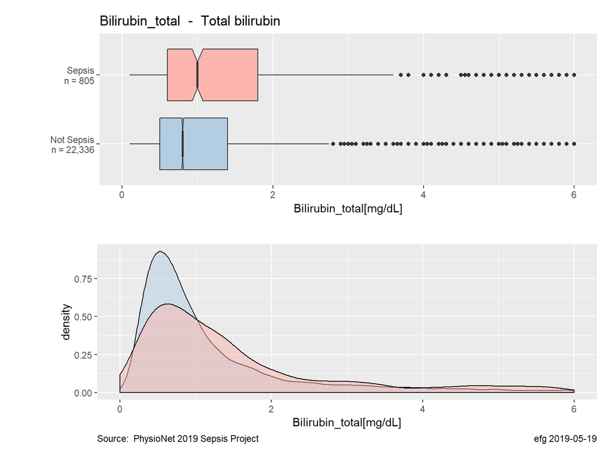

| Sepsis | N | Distinct | Mean | StdDev | Skewness | Kurtosis | Min | Q5 | Q25 | Median | Q75 | Q95 | Max |
| --- | --- | --- | --- | --- | --- | --- | --- | --- | --- | --- | --- | --- | --- |
| Sepsis | 805 | 407 | 3.195776 | 6.025226 | 3.904222 | 17.31506 | 0.1 | 0.3 | 0.6 | 1.2 | 2.6 | 16.080 | 45.9 |
| Not Sepsis | 22,336 | 407 | 2.075074 | 4.231811 | 5.335802 | 34.81609 | 0.1 | 0.3 | 0.5 | 0.8 | 1.6 | 8.025 | 49.6 |

### 3.3.6 BUN - Blood urea nitrogen

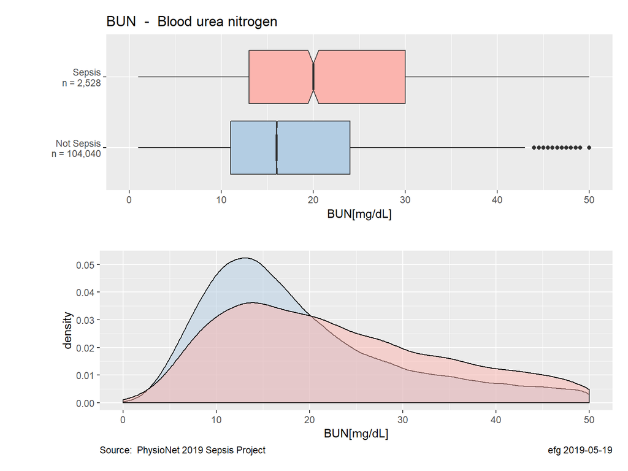

| Sepsis | N | Distinct | Mean | StdDev | Skewness | Kurtosis | Min | Q5 | Q25 | Median | Q75 | Q95 | Max |
| --- | --- | --- | --- | --- | --- | --- | --- | --- | --- | --- | --- | --- | --- |
| Sepsis | 2,528 | 265 | 30.77373 | 23.12890 | 1.723842 | 3.751362 | 1 | 7 | 14 | 24 | 40 | 79 | 182 |
| Not Sepsis | 104,040 | 265 | 23.74881 | 19.88272 | 2.560820 | 9.446662 | 1 | 6 | 12 | 17 | 28 | 64 | 268 |

### 3.3.7 Calcium

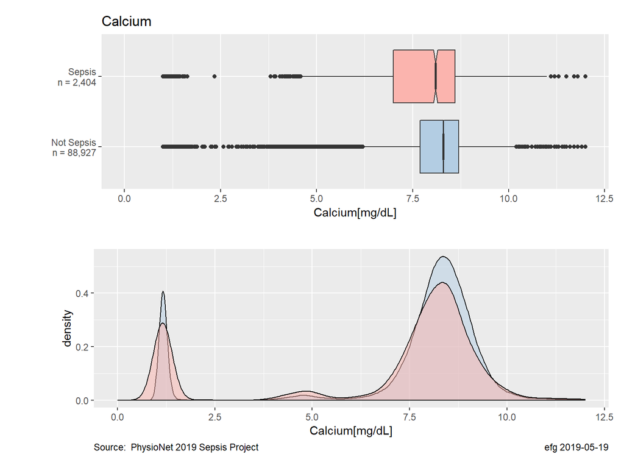

| Sepsis | N | Distinct | Mean | StdDev | Skewness | Kurtosis | Min | Q5 | Q25 | Median | Q75 | Q95 | Max |
| --- | --- | --- | --- | --- | --- | --- | --- | --- | --- | --- | --- | --- | --- |
| Sepsis | 2,404 | 549 | 6.966726 | 2.910244 | -1.052786 | 0.5638587 | 1 | 1.11 | 7.075 | 8.1 | 8.6 | 9.6 | 20.0 |
| Not Sepsis | 88,927 | 549 | 7.573502 | 2.416964 | -1.661938 | 3.4309684 | 1 | 1.17 | 7.700 | 8.3 | 8.8 | 9.5 | 27.9 |

### 3.3.8 Chloride

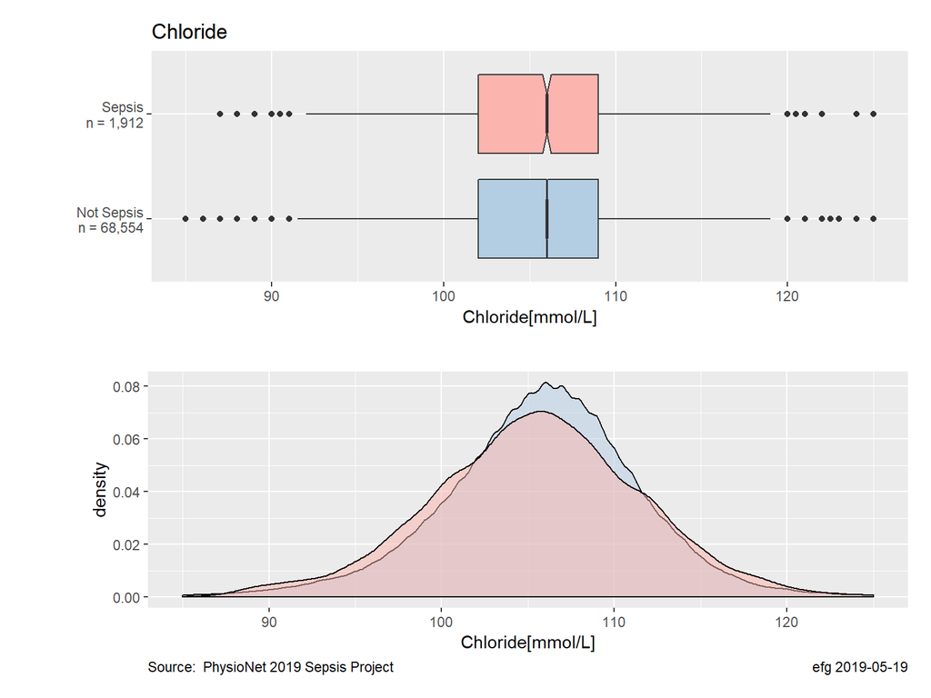

| Sepsis | N | Distinct | Mean | StdDev | Skewness | Kurtosis | Min | Q5 | Q25 | Median | Q75 | Q95 | Max |
| --- | --- | --- | --- | --- | --- | --- | --- | --- | --- | --- | --- | --- | --- |
| Sepsis | 1,912 | 108 | 105.4626 | 6.280804 | -0.1531359 | 0.847956 | 73 | 95 | 101 | 106 | 109 | 115 | 128 |
| Not Sepsis | 68,554 | 108 | 105.8381 | 5.868628 | -0.1636823 | 2.776807 | 26 | 96 | 102 | 106 | 109 | 115 | 145 |

### 3.3.9 Creatinine

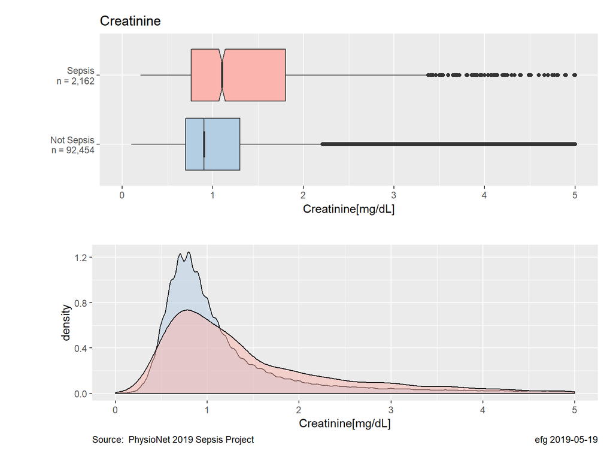

| Sepsis | N | Distinct | Mean | StdDev | Skewness | Kurtosis | Min | Q5 | Q25 | Median | Q75 | Q95 | Max |
| --- | --- | --- | --- | --- | --- | --- | --- | --- | --- | --- | --- | --- | --- |
| Sepsis | 2,162 | 1,407 | 1.847595 | 1.881989 | 3.157481 | 14.34021 | 0.2 | 0.5 | 0.8 | 1.20 | 2.10 | 5.6095 | 19.51 |
| Not Sepsis | 92,454 | 1,407 | 1.502821 | 1.803035 | 4.673541 | 34.49514 | 0.1 | 0.5 | 0.7 | 0.93 | 1.41 | 4.8600 | 46.60 |

### 3.3.10 Fibrinogen

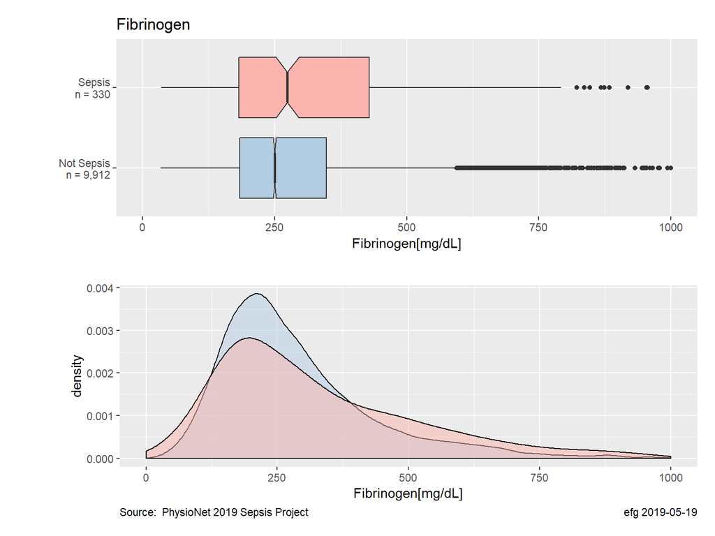

| Sepsis | N | Distinct | Mean | StdDev | Skewness | Kurtosis | Min | Q5 | Q25 | Median | Q75 | Q95 | Max |
| --- | --- | --- | --- | --- | --- | --- | --- | --- | --- | --- | --- | --- | --- |
| Sepsis | 330 | 823 | 327.8333 | 197.5433 | 1.211454 | 1.195518 | 35 | 111.45 | 182.25 | 274.5 | 433 | 725.00 | 1,051 |
| Not Sepsis | 9,912 | 823 | 286.0391 | 151.1214 | 1.611700 | 4.172383 | 34 | 112.00 | 184.00 | 250.0 | 348 | 593.45 | 1,760 |

### 3.3.11 FiO2 - Fraction of inspired oxygen

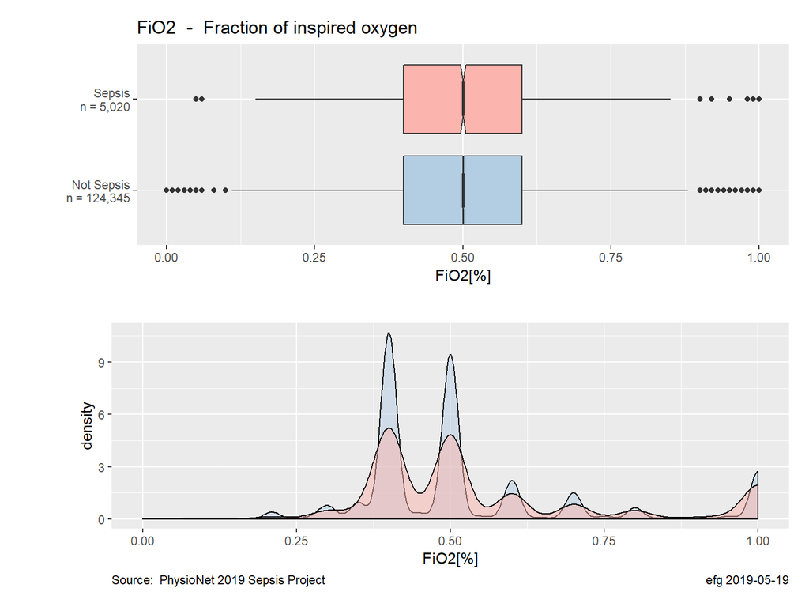

| Sepsis | N | Distinct | Mean | StdDev | Skewness | Kurtosis | Min | Q5 | Q25 | Median | Q75 | Q95 | Max |
| --- | --- | --- | --- | --- | --- | --- | --- | --- | --- | --- | --- | --- | --- |
| Sepsis | 5,020 | 104 | 0.5524761 | 0.2071295 | 1.323121 | 1.540156e+00 | 0.05 | 0.35 | 0.4 | 0.5 | 0.6 | 1 | 2 |
| Not Sepsis | 124,345 | 104 | 0.5549340 | 11.3454414 | 352.293760 | 1.241865e+05 | -50.00 | 0.35 | 0.4 | 0.5 | 0.6 | 1 | 4,000 |

### 3.3.12 Glucose - Serum glucose

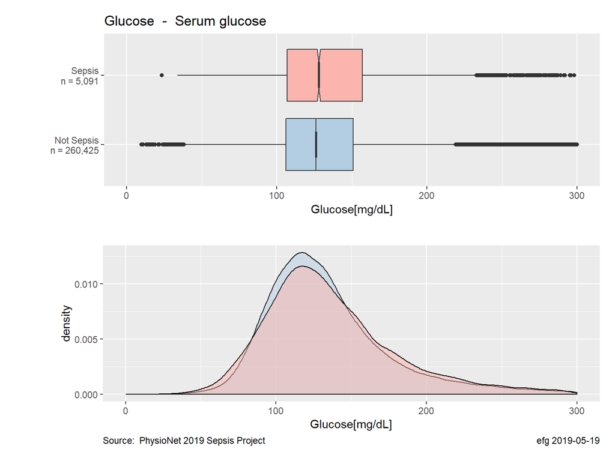

| Sepsis | N | Distinct | Mean | StdDev | Skewness | Kurtosis | Min | Q5 | Q25 | Median | Q75 | Q95 | Max |
| --- | --- | --- | --- | --- | --- | --- | --- | --- | --- | --- | --- | --- | --- |
| Sepsis | 5,091 | 1,157 | 140.0292 | 54.21646 | 2.289816 | 10.71366 | 23.5 | 79 | 107 | 129.0 | 159 | 239 | 733 |
| Not Sepsis | 260,425 | 1,157 | 136.8717 | 51.25053 | 2.830084 | 17.86757 | 10.0 | 82 | 106 | 126.5 | 153 | 229 | 988 |

### 3.3.13 HCO3 - Bicarbonate

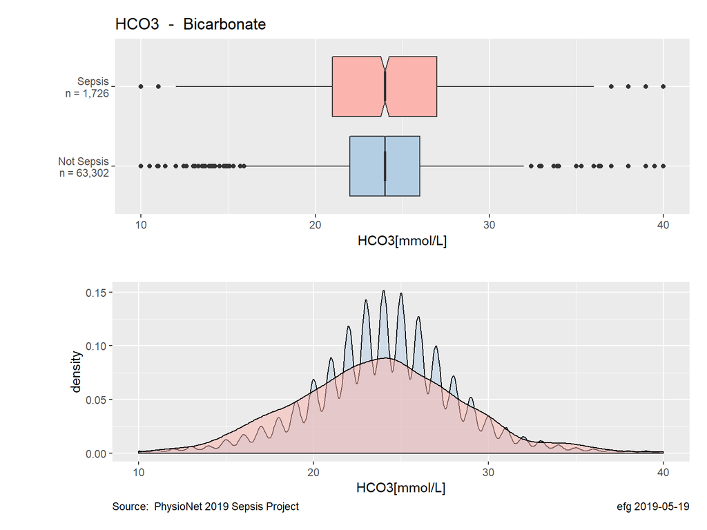

| Sepsis | N | Distinct | Mean | StdDev | Skewness | Kurtosis | Min | Q5 | Q25 | Median | Q75 | Q95 | Max |
| --- | --- | --- | --- | --- | --- | --- | --- | --- | --- | --- | --- | --- | --- |
| Sepsis | 1,726 | 304 | 23.70214 | 4.916893 | 0.1186035 | 0.5685474 | 5 | 16 | 20.6875 | 24 | 27.0 | 31.875 | 45 |
| Not Sepsis | 63,302 | 304 | 24.08566 | 4.360428 | 0.1572827 | 2.1981732 | 0 | 17 | 22.0000 | 24 | 26.4 | 31.000 | 55 |

### 3.3.14 Hct - Hematocrit

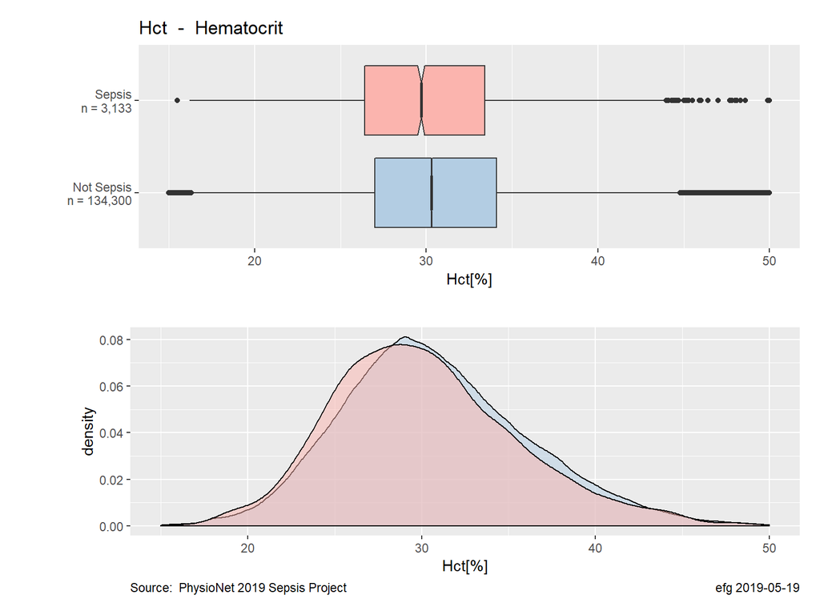

| Sepsis | N | Distinct | Mean | StdDev | Skewness | Kurtosis | Min | Q5 | Q25 | Median | Q75 | Q95 | Max |
| --- | --- | --- | --- | --- | --- | --- | --- | --- | --- | --- | --- | --- | --- |
| Sepsis | 3,133 | 725 | 30.25738 | 5.507831 | 0.7556947 | 1.7045614 | 14.4 | 22.5 | 26.4 | 29.8 | 33.5 | 40.3 | 65.0 |
| Not Sepsis | 134,300 | 725 | 30.80661 | 5.490767 | 0.4666819 | 0.6112753 | 5.5 | 22.7 | 27.0 | 30.3 | 34.1 | 40.6 | 71.7 |

### 3.3.15 Hgb - Hemoglobin

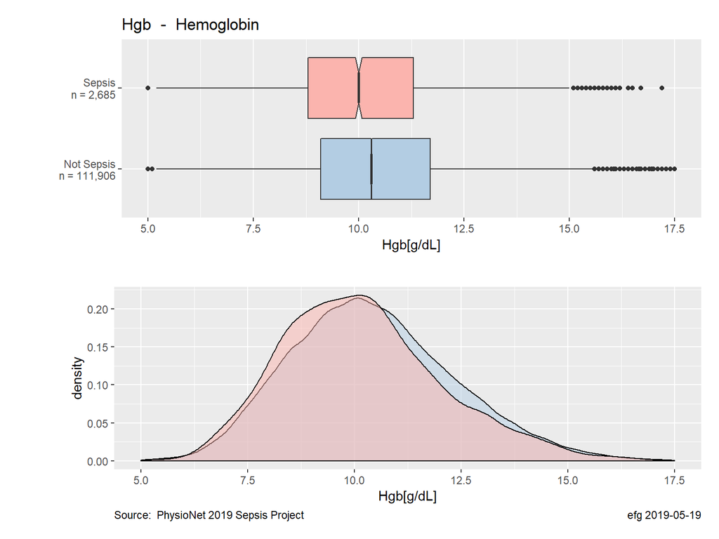

| Sepsis | N | Distinct | Mean | StdDev | Skewness | Kurtosis | Min | Q5 | Q25 | Median | Q75 | Q95 | Max |
| --- | --- | --- | --- | --- | --- | --- | --- | --- | --- | --- | --- | --- | --- |
| Sepsis | 2,685 | 340 | 10.19506 | 1.928865 | 0.6868533 | 1.0743216 | 4.6 | 7.4 | 8.8 | 10.0 | 11.3 | 13.7 | 21 |
| Not Sepsis | 111,906 | 340 | 10.43649 | 1.969267 | 0.4775321 | 0.8833878 | 2.2 | 7.5 | 9.1 | 10.3 | 11.7 | 13.9 | 32 |

### 3.3.16 Lactate - Lactic acid

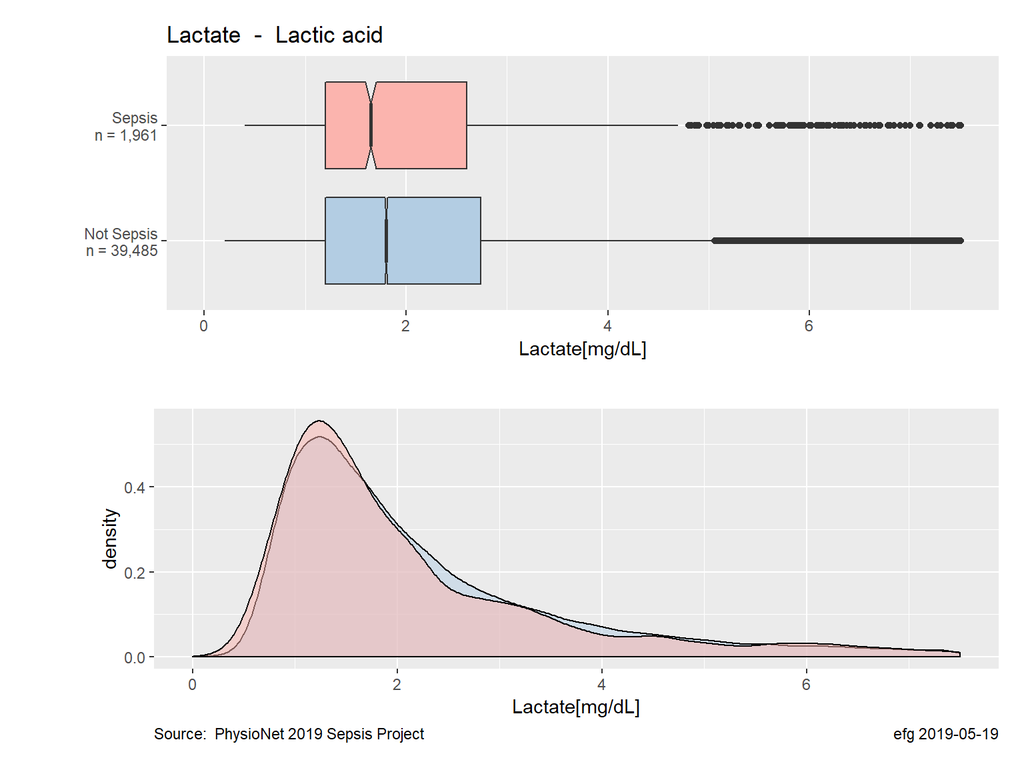

| Sepsis | N | Distinct | Mean | StdDev | Skewness | Kurtosis | Min | Q5 | Q25 | Median | Q75 | Q95 | Max |
| --- | --- | --- | --- | --- | --- | --- | --- | --- | --- | --- | --- | --- | --- |
| Sepsis | 1,961 | 1,340 | 2.726364 | 2.816799 | 3.080208 | 11.59842 | 0.4 | 0.8 | 1.20 | 1.7 | 3 | 8.5 | 21.52 |
| Not Sepsis | 39,485 | 1,340 | 2.642708 | 2.510880 | 3.423934 | 16.29806 | 0.2 | 0.8 | 1.27 | 1.8 | 3 | 7.3 | 31.00 |

### 3.3.17 Magnesium

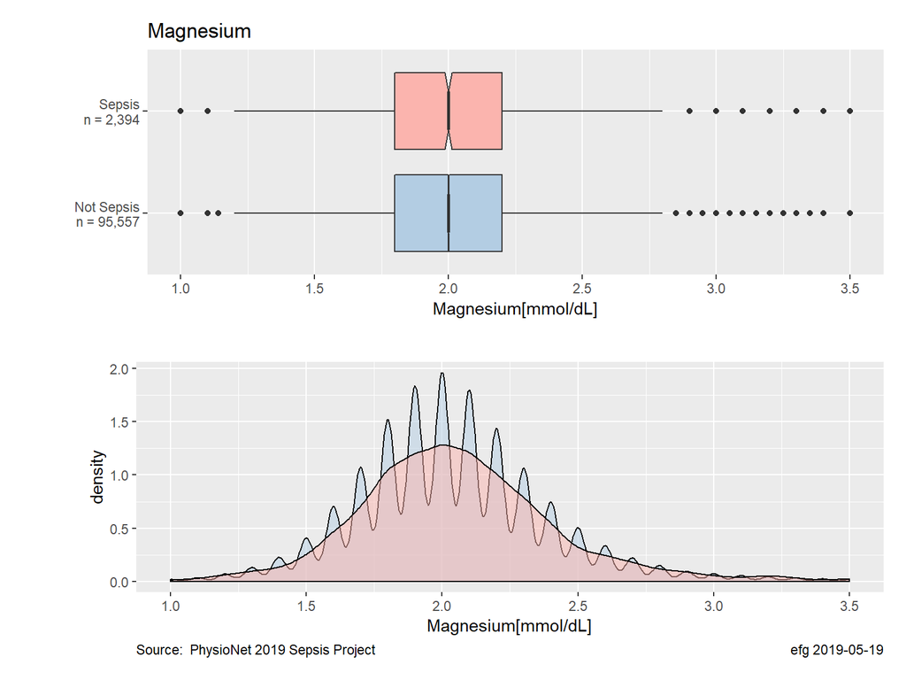

| Sepsis | N | Distinct | Mean | StdDev | Skewness | Kurtosis | Min | Q5 | Q25 | Median | Q75 | Q95 | Max |
| --- | --- | --- | --- | --- | --- | --- | --- | --- | --- | --- | --- | --- | --- |
| Sepsis | 2,394 | 110 | 2.067064 | 0.4163226 | 3.064088 | 34.27592 | 0.9 | 1.5 | 1.8 | 2 | 2.3 | 2.7 | 8.2 |
| Not Sepsis | 95,557 | 110 | 2.051059 | 0.3974196 | 2.254333 | 21.81491 | 0.2 | 1.5 | 1.8 | 2 | 2.2 | 2.7 | 9.8 |

### 3.3.18 PaCO2 - Partial pressure of carbon dioxide from arterial blood

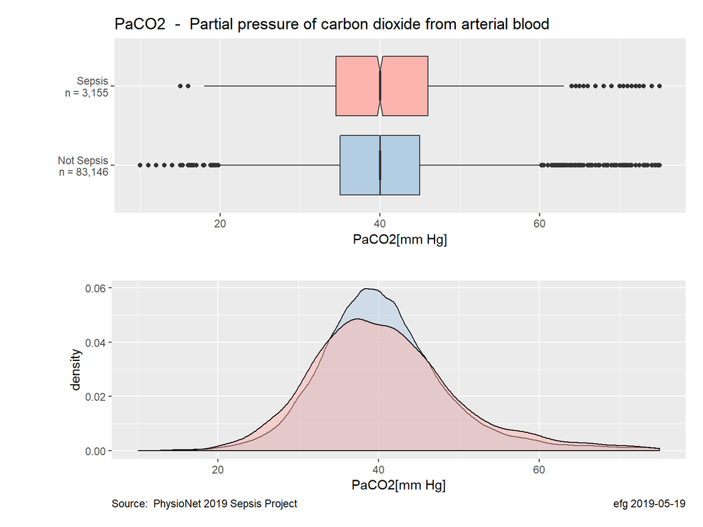

| Sepsis | N | Distinct | Mean | StdDev | Skewness | Kurtosis | Min | Q5 | Q25 | Median | Q75 | Q95 | Max |
| --- | --- | --- | --- | --- | --- | --- | --- | --- | --- | --- | --- | --- | --- |
| Sepsis | 3,155 | 551 | 41.72285 | 11.226366 | 1.591865 | 4.283962 | 15 | 28 | 35.0 | 40 | 46 | 62 | 100 |
| Not Sepsis | 83,146 | 551 | 40.99527 | 9.183705 | 1.560085 | 5.506358 | 10 | 29 | 35.4 | 40 | 45 | 57 | 100 |

### 3.3.19 pH - Measure of acidity or basicity

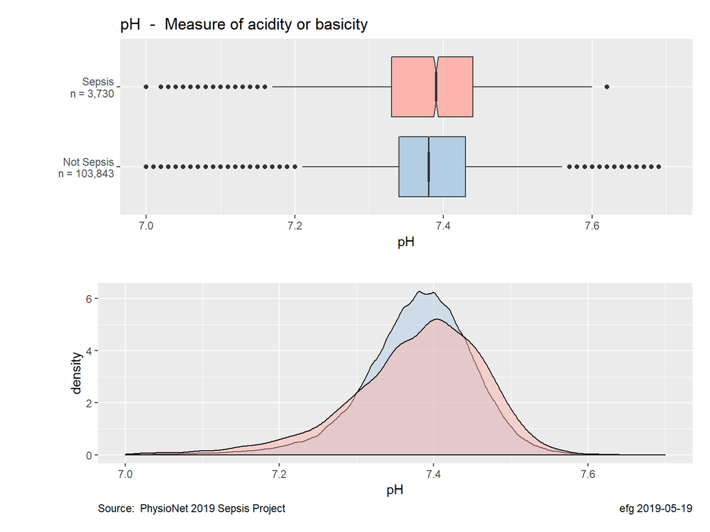

| Sepsis | N | Distinct | Mean | StdDev | Skewness | Kurtosis | Min | Q5 | Q25 | Median | Q75 | Q95 | Max |
| --- | --- | --- | --- | --- | --- | --- | --- | --- | --- | --- | --- | --- | --- |
| Sepsis | 3,730 | 103 | 7.377110 | 0.0901666 | -1.0672453 | 2.494957 | 6.81 | 7.21 | 7.33 | 7.39 | 7.44 | 7.50 | 7.62 |
| Not Sepsis | 103,843 | 103 | 7.378999 | 0.0739459 | -0.9225471 | 3.762610 | 6.62 | 7.26 | 7.34 | 7.38 | 7.43 | 7.49 | 7.93 |

### 3.3.20 Phosphate

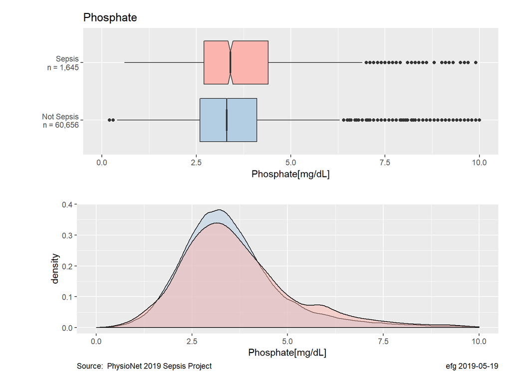

| Sepsis | N | Distinct | Mean | StdDev | Skewness | Kurtosis | Min | Q5 | Q25 | Median | Q75 | Q95 | Max |
| --- | --- | --- | --- | --- | --- | --- | --- | --- | --- | --- | --- | --- | --- |
| Sepsis | 1,645 | 193 | 3.716960 | 1.592900 | 1.466567 | 3.651038 | 0.6 | 1.7 | 2.7 | 3.4 | 4.4 | 6.7 | 12.0 |
| Not Sepsis | 60,656 | 193 | 3.539553 | 1.418125 | 1.687727 | 6.052182 | 0.2 | 1.7 | 2.6 | 3.3 | 4.1 | 6.1 | 18.8 |

### 3.3.21 Platelets

Units updated after PhysioNet forum posting by Gari Clifford on 2019-04-17

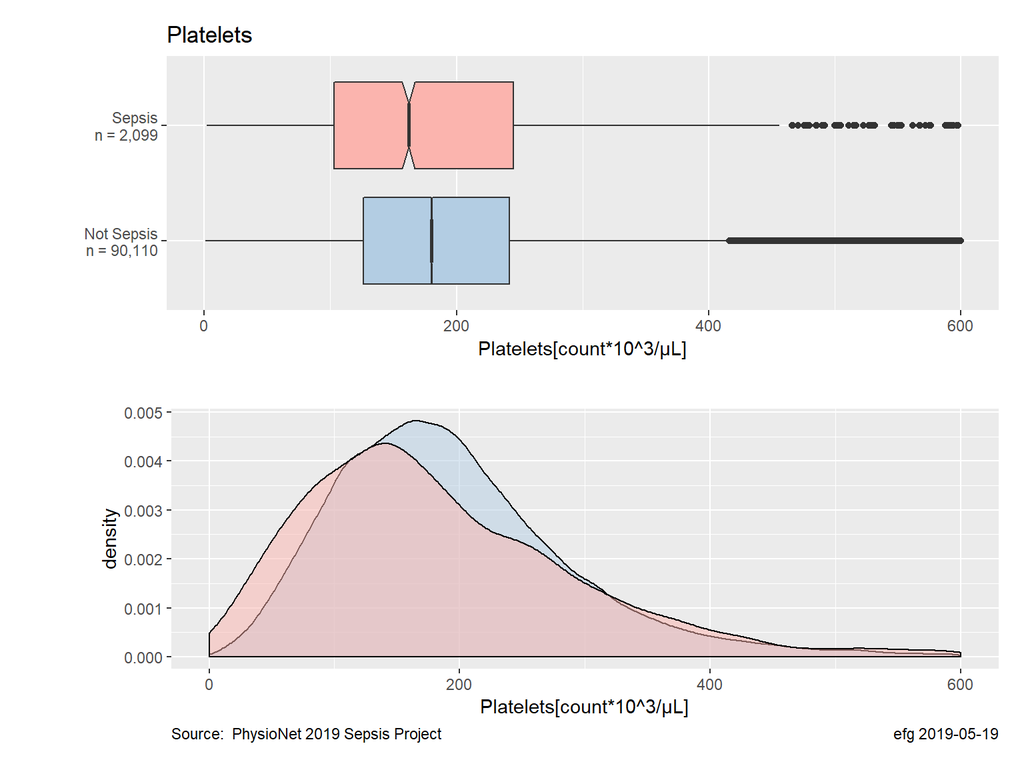

| Sepsis | N | Distinct | Mean | StdDev | Skewness | Kurtosis | Min | Q5 | Q25 | Median | Q75 | Q95 | Max |
| --- | --- | --- | --- | --- | --- | --- | --- | --- | --- | --- | --- | --- | --- |
| Sepsis | 2,099 | 989 | 187.854 | 118.4954 | 1.468264 | 3.830503 | 2 | 43 | 104 | 163 | 248 | 407.1 | 1,081 |
| Not Sepsis | 90,110 | 989 | 196.204 | 103.2568 | 1.853843 | 10.021401 | 1 | 66 | 127 | 181 | 244 | 378.0 | 2,322 |

### 3.3.22 Potassium

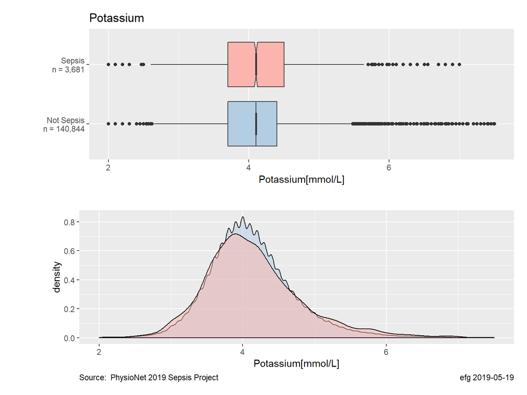

| Sepsis | N | Distinct | Mean | StdDev | Skewness | Kurtosis | Min | Q5 | Q25 | Median | Q75 | Q95 | Max |
| --- | --- | --- | --- | --- | --- | --- | --- | --- | --- | --- | --- | --- | --- |
| Sepsis | 3,681 | 402 | 4.158788 | 0.7170678 | 1.260672 | 4.158421 | 2 | 3.2 | 3.7 | 4.1 | 4.5 | 5.5 | 9.4 |
| Not Sepsis | 140,844 | 402 | 4.134920 | 0.6400658 | 1.730112 | 19.734159 | 1 | 3.3 | 3.7 | 4.1 | 4.4 | 5.2 | 27.5 |

### 3.3.23 PTT - partial thromboplastin time

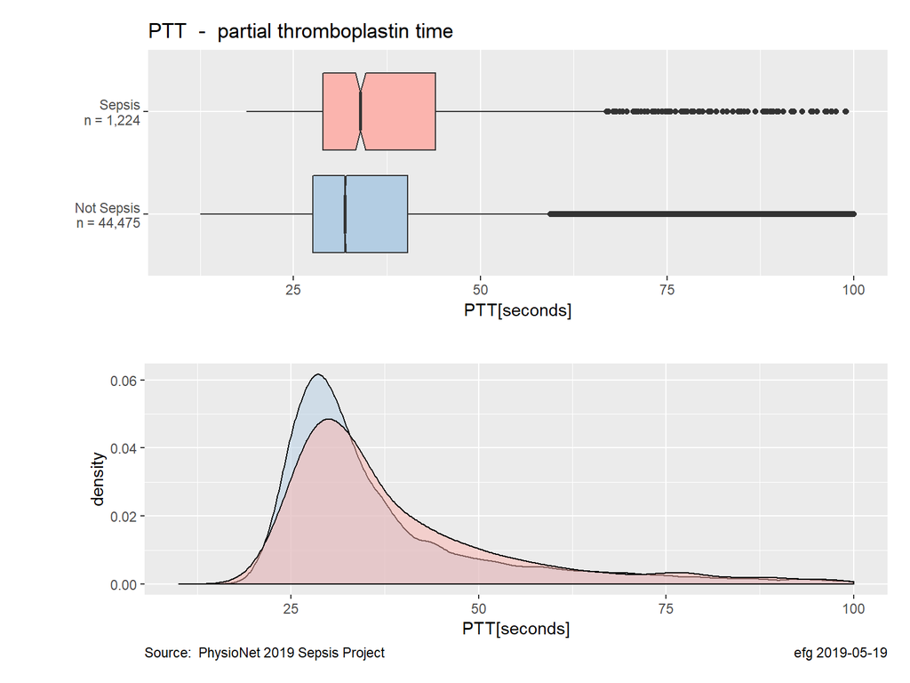

| Sepsis | N | Distinct | Mean | StdDev | Skewness | Kurtosis | Min | Q5 | Q25 | Median | Q75 | Q95 | Max |
| --- | --- | --- | --- | --- | --- | --- | --- | --- | --- | --- | --- | --- | --- |
| Sepsis | 1,224 | 1,410 | 43.99281 | 28.02401 | 3.320228 | 14.84276 | 18.7 | 24.0 | 29.1 | 34.5 | 46.8 | 97.085 | 249.9 |
| Not Sepsis | 44,475 | 1,410 | 41.15519 | 26.16241 | 3.462178 | 15.93594 | 12.5 | 23.5 | 27.8 | 32.3 | 42.6 | 91.830 | 250.0 |

### 3.3.24 SaO2 - Oxygen saturation from arterial blood

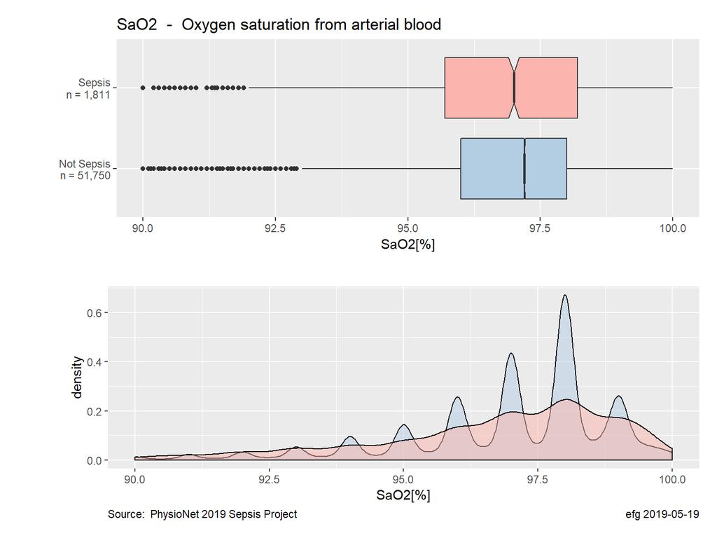

| Sepsis | N | Distinct | Mean | StdDev | Skewness | Kurtosis | Min | Q5 | Q25 | Median | Q75 | Q95 | Max |
| --- | --- | --- | --- | --- | --- | --- | --- | --- | --- | --- | --- | --- | --- |
| Sepsis | 1,811 | 432 | 93.23564 | 9.907248 | -2.987391 | 9.785204 | 23 | 68 | 93.95 | 97 | 98 | 99.4 | 100 |
| Not Sepsis | 51,750 | 432 | 92.63384 | 10.925399 | -2.377657 | 4.913630 | 24 | 64 | 94.10 | 97 | 98 | 99.1 | 100 |

### 3.3.25 TroponinI - Troponinl

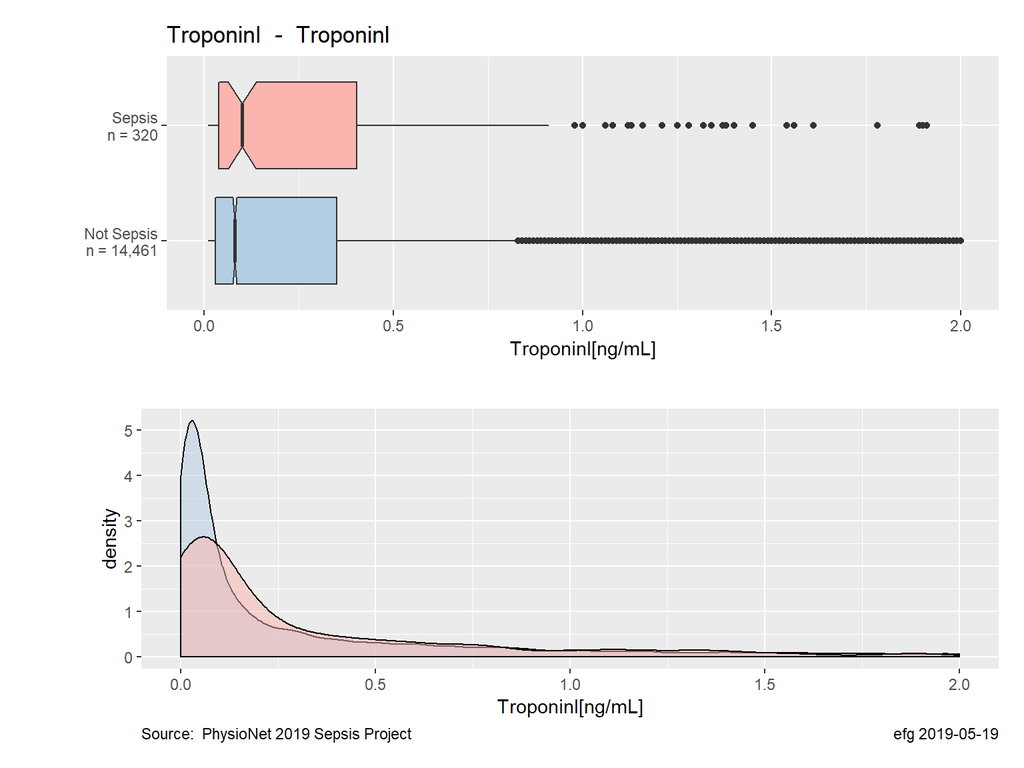

| Sepsis | N | Distinct | Mean | StdDev | Skewness | Kurtosis | Min | Q5 | Q25 | Median | Q75 | Q95 | Max |
| --- | --- | --- | --- | --- | --- | --- | --- | --- | --- | --- | --- | --- | --- |
| Sepsis | 320 | 2,423 | 9.534187 | 31.29098 | 4.801923 | 24.04744 | 0.01 | 0.01 | 0.06 | 0.265 | 2.3775 | 40.5 | 200 |
| Not Sepsis | 14,461 | 2,423 | 8.262570 | 24.64410 | 6.443542 | 60.41305 | 0.01 | 0.01 | 0.04 | 0.300 | 4.0000 | 40.0 | 440 |

### 3.3.26 WBC - Leukocyte count

Units updated after PhysioNet forum posting by Gari Clifford on 2019-04-17

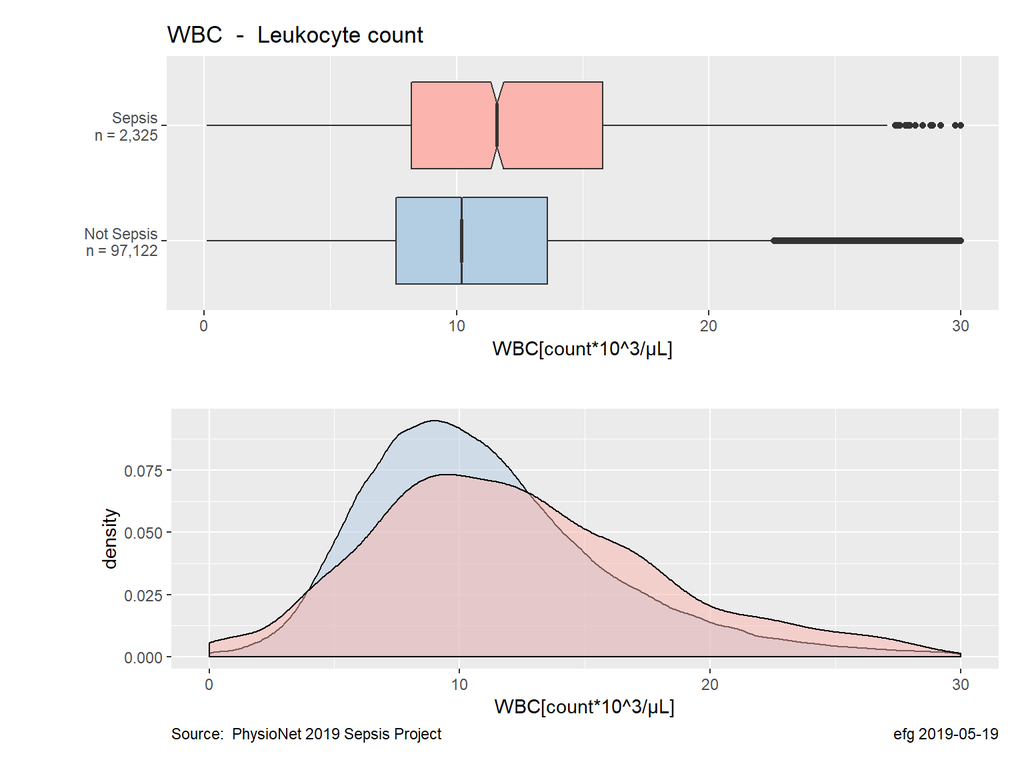

| Sepsis | N | Distinct | Mean | StdDev | Skewness | Kurtosis | Min | Q5 | Q25 | Median | Q75 | Q95 | Max |
| --- | --- | --- | --- | --- | --- | --- | --- | --- | --- | --- | --- | --- | --- |
| Sepsis | 2,325 | 891 | 13.32593 | 9.721607 | 6.62498 | 83.13563 | 0.1 | 4.0 | 8.3 | 11.8 | 16.2 | 26.3 | 168.6 |
| Not Sepsis | 97,122 | 891 | 11.40141 | 7.671458 | 15.31419 | 559.21400 | 0.1 | 4.5 | 7.6 | 10.3 | 13.7 | 21.1 | 440.0 |

Notes:

- StackOverflow [R dplyr operate on a column known only by its string name](https://stackoverflow.com/questions/46310123/r-dplyr-operate-on-a-column-known-only-by-its-string-name).
- StackOverflow [Using dplyr window functions to calculate percentiles](https://stackoverflow.com/questions/30488389/using-dplyr-window-functions-to-calculate-percentiles).

# 4 Discussion

Need to impose limits since outliers distort some charts too much.

[work in progress]

# 5 Conclusions

[work in progress]

# 6 sessionInfo

```r
library(rmarkdown)
pandoc_version()
```

```
## [1] '2.7.1'
```

Processing time: 43.8 secs

2019-05-19 0048